# Agujeros grandes en taladro de banco

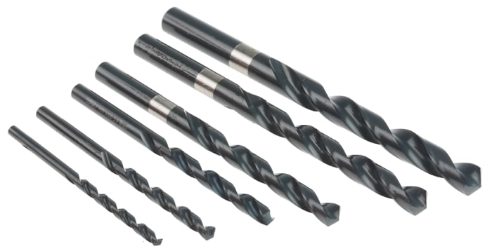

Set de brocas helicoidales para hacer agujeros progresivos.

El **taladro de banco** es una máquina muy utilizada en el taller. Su uso correcto permite obtener perforaciones más precisas y alargar la vida de las herramientas (las brocas).

Aquí aprenderás buenas prácticas para realizar agujeros grandes (de 12 mm o más) en un taladro de banco. Existen otras máquinas de mayor potencia y producción que pueden emplear métodos distintos.

## Procedimiento básico

- Para **agujeros grandes**, se recomienda trabajar **en pasos progresivos**: comenzar con una mecha pequeña y luego aumentar el diámetro en una o dos etapas hasta alcanzar la medida final.
- Esto reduce el esfuerzo sobre la máquina y evita que la mecha se trabe o se desgaste prematuramente.

**(En inglés)**

**Basic procedure**

- For large holes, it is recommended to work in progressive steps: start with a small drill bit and then increase the diameter in one or two stages until reaching the final size.
- This reduces the stress on the machine and prevents the drill bit from jamming or wearing out prematurely.

## Técnica (pasos prácticos)

1. Marcar el centro con la punta de marcar.
2. Ubicar y fijar la pieza con una prensa o morsa para taladro. Hacerlo de modo que puedas intercambiar las brocas sin necesidad de mover la posición de la pieza.
3. Hacer un **agujero guía** con una mecha fina (por ejemplo 3–6 mm). Sirve como referencia y evita que la mecha grande “camine”.
4. Aumentar el diámetro en etapas usando mechas intermedias sin forzar la máquina.
5. Aplicar refrigeración: un poco de fluido refrigerante cada cierto tiempo o un chorro continuo de acuerdo a la necesidad. Esto reduce el calor, aumenta la duración del filo y mejora la terminación. Si el taladro no tiene un sistema de fábrica se debe recoger el fluido por abajo en algún recipiente. Esto facilita la limpieza y permite rehusarlo.

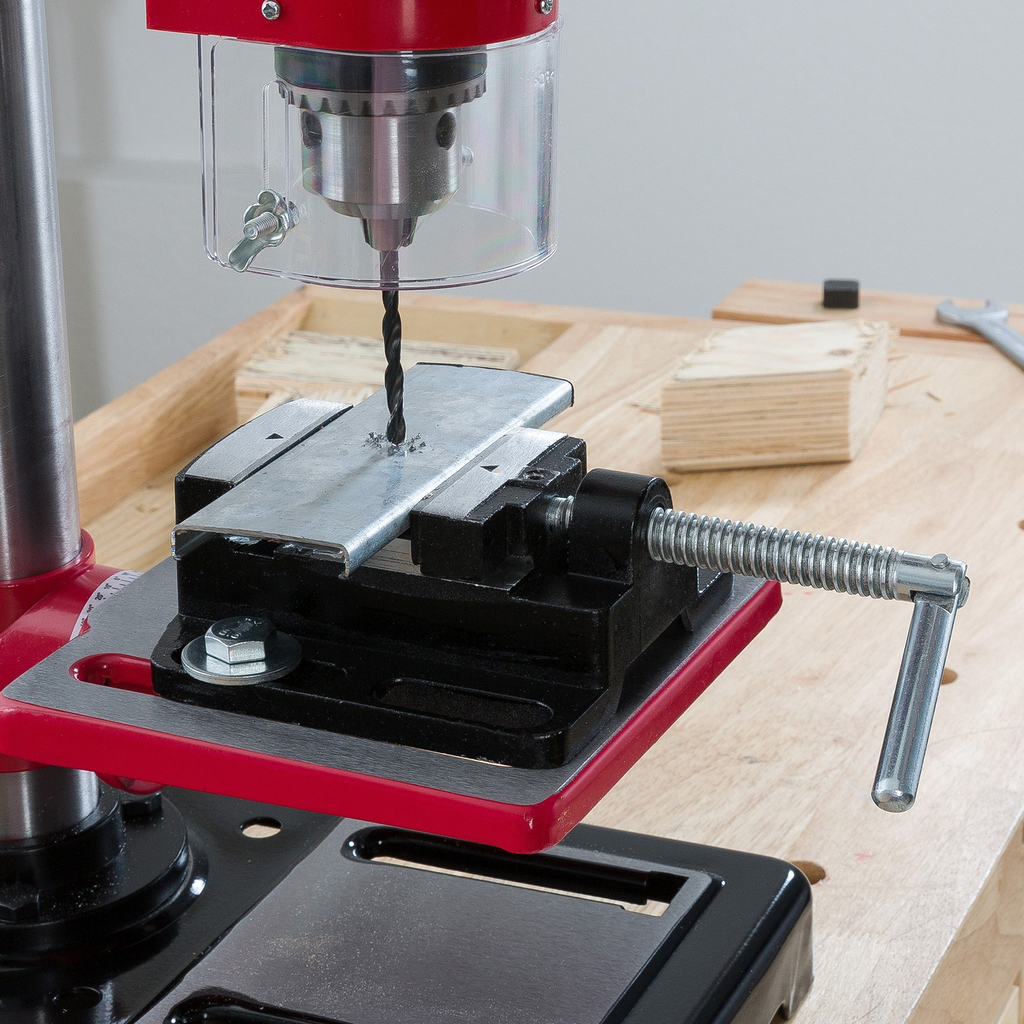

Una vez sujeta la pieza deberías poder cambiar mechas sin mover la sujección. Fuente: elegance.com

**Otros tips de taller:**

- Reducir la velocidad al aumentar el diámetro: las brocas grandes requieren menor rpm.
- Especialmente en agujeros largos, donde es posible que no salga la viruta tan fácilmente, hay que retirar virutas frecuentemente mientras se agujerea para evitar el bloqueo y posible rotura de la broca.

## Refrigeración y lubricación

- Durante la perforación se emplea un **fluido refrigerante**, normalmente una mezcla de **agua con aceite soluble** (emulsión de color lechoso).
- El agua absorbe el calor y el aceite lubrica, facilitando el corte y ayudando a evacuar la viruta.
- La emulsión contiene entre 5% y 10% de aceite en agua (es decir, 1 parte de aceite soluble cada 10–20 partes de agua). Para trabajos livianos en taladro de banco alcanza con 5%.

## Cuidado de la máquina

- Como el refrigerante contiene agua, puede producir **oxidación** si queda en la mesa, mordazas o partes metálicas de la máquina.
- Por eso, al terminar el trabajo es necesario:
  1. **Secar la superficie** y retirar los restos de fluido y viruta.
  2. Pasar un **trapo con aceite liviano** sobre la mesa y zonas expuestas.
  3. Dejar el área de trabajo **limpia y ordenada**, siguiendo los principios de las **5S** que también se aplican en la industria.

## Otros modos de hacer agujeros grandes

De acuerdo al trabajo y a los materiales también se pueden emplear las siguientes herramientas:

### Con brocas escalonadas

[figure not shown]

Fuente: Bahco

- Están diseñadas sobre todo para láminas metálicas finas (acero al carbono, aluminio, chapa galvanizada, plásticos).
- Se usan mucho en electricidad, aire acondicionado, montaje de tableros o en producción ligera donde hay que perforar chapas con distintos diámetros.
- No sirven para agujeros profundos ni para arranque pesado de viruta: en materiales duros o espesores grandes se desgastan rápido.

### Con sierras corona (brocas corona)

[figure not shown]

Fuente: ferreteriaprosperidad.es

- Se emplean para hacer agujeros grandes (mucho más grandes que con una broca común).
- Trabajan bien en materiales blandos o medianos: madera, plásticos, aluminio, chapa fina.
- En acero más grueso también se usan, pero requieren baja velocidad y buen refrigerante, porque generan bastante calor.
- Se valoran en instalaciones eléctricas, plomería y herrería ligera, donde hay que abrir paso para caños, cajas o conductos.